# SI_02_GRANT_US_ORG_ADDR_CITY

Grantee city · Text report

## Overview

**Description**

Address Foreign - City

**Table**

`SI-P02-T01-GRANTS-US-ORGS-GOVTS` (many)

**Location code**

`SCHED-I-PART-02-LINE-01-COL-A`

**Family**

`SCHED-I-PART-02-LINE-01-COL-A` · siblings: SI_02_GRANT_US_ORG_ADDR_CNTR, SI_02_GRANT_US_ORG_ADDR_L1, SI_02_GRANT_US_ORG_ADDR_L2, SI_02_GRANT_US_ORG_ADDR_STATE, SI_02_GRANT_US_ORG_ADDR_ZIP, SI_02_GRANT_US_ORG_NAME_L1

**Data type**

text (xsd: , TextType, CityType)

**Scope**

PC

**Status**

unreviewed

8

xpaths mapped (6 observed)

531,545

filings with a value

2009–2024

tax years observed

3

open flags (1 errors)

## Flags

| Severity | Flag | Xpath | Detail |
| --- | --- | --- | --- |
| ⚠ error | `COLLISION` | IRS990ScheduleI/RecipientTable/ForeignAddress/CityNm | 1517 filings contain 2+ of its xpaths; most common set: /Return/ReturnData/IRS990ScheduleI/RecipientTable/ForeignAddress/CityNm ; /Return/ReturnData/IRS990ScheduleI/RecipientTable/USAddress/CityNm |
| ⓘ info | `UNOBSERVED` | IRS990ScheduleI/Form990ScheduleIPartII/RecipientTable/AddressForeign/City | never observed in TY2009-2024 filings |
| ⓘ info | `UNOBSERVED` | IRS990ScheduleI/Form990ScheduleIPartII/RecipientTable/AddressUS/City | never observed in TY2009-2024 filings |

## Xpaths

All mapped xpaths (under /Return/ReturnData or /Return/ReturnHeader), oldest first. Charts label each series by its xpath.

| Xpath | Form | Chart label | First year | Last year | Versions | Filings | Repeats in |
| --- | --- | --- | --- | --- | --- | --- | --- |
| IRS990ScheduleI/RecipientTable/AddressUS/City | Sched I | same | 2009 | 2012 | 18 | 68,775 | 51.5% |
| IRS990ScheduleI/RecipientTable/AddressForeign/City | Sched I | same | 2009 | 2012 | 13 | 185 | 21.1% |
| IRS990ScheduleI/RecipientTable/USAddress/City | Sched I | same | 2013 | 2013 | 3 | 27,474 | 50.2% |
| IRS990ScheduleI/RecipientTable/ForeignAddress/City | Sched I | same | 2013 | 2013 | 3 | 91 | 13.2% |
| IRS990ScheduleI/RecipientTable/USAddress/CityNm | Sched I | same | 2014 | 2024 | 34 | 433,436 | 50.9% |
| IRS990ScheduleI/RecipientTable/ForeignAddress/CityNm | Sched I | same | 2014 | 2024 | 33 | 1,584 | 23.3% |
| IRS990ScheduleI/Form990ScheduleIPartII/RecipientTable/AddressForeign/City | Sched I | …Form990ScheduleIPartII/RecipientTable/AddressForeign/City |  |  |  | 0 |  |
| IRS990ScheduleI/Form990ScheduleIPartII/RecipientTable/AddressUS/City | Sched I | …uleI/Form990ScheduleIPartII/RecipientTable/AddressUS/City |  |  |  | 0 |  |

## Coverage

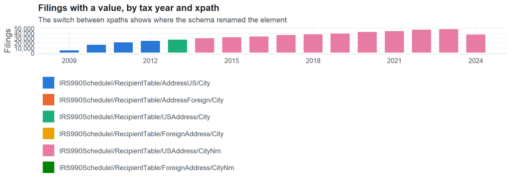

**Table view**

Table view: filings by tax year and series

| Tax year | IRS990ScheduleI/RecipientTable/AddressUS/City | IRS990ScheduleI/RecipientTable/AddressForeign/City | IRS990ScheduleI/RecipientTable/USAddress/City | IRS990ScheduleI/RecipientTable/ForeignAddress/City | IRS990ScheduleI/RecipientTable/USAddress/CityNm | IRS990ScheduleI/RecipientTable/ForeignAddress/CityNm |
| --- | --- | --- | --- | --- | --- | --- |
| 2009 | 5,375 | 16 | 0 | 0 | 0 | 0 |
| 2010 | 16,862 | 48 | 0 | 0 | 0 | 0 |
| 2011 | 21,884 | 58 | 0 | 0 | 0 | 0 |
| 2012 | 24,654 | 63 | 0 | 0 | 0 | 0 |
| 2013 | 0 | 0 | 27,474 | 91 | 0 | 0 |
| 2014 | 0 | 0 | 0 | 0 | 30,396 | 92 |
| 2015 | 0 | 0 | 0 | 0 | 32,477 | 93 |
| 2016 | 0 | 0 | 0 | 0 | 33,945 | 126 |
| 2017 | 0 | 0 | 0 | 0 | 36,928 | 150 |
| 2018 | 0 | 0 | 0 | 0 | 38,292 | 146 |
| 2019 | 0 | 0 | 0 | 0 | 39,702 | 132 |
| 2020 | 0 | 0 | 0 | 0 | 43,091 | 140 |
| 2021 | 0 | 0 | 0 | 0 | 44,833 | 179 |
| 2022 | 0 | 0 | 0 | 0 | 47,425 | 195 |
| 2023 | 0 | 0 | 0 | 0 | 48,715 | 187 |
| 2024 | 0 | 0 | 0 | 0 | 37,632 | 144 |

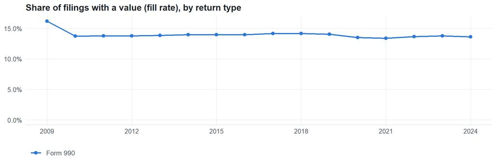

**Table view**

Table view: fill rate

| Tax year | Return type | Filings | All filings | Fill rate |
| --- | --- | --- | --- | --- |
| 2009 | Form 990 | 5,391 | 33,311 | 16.18% |
| 2010 | Form 990 | 16,910 | 123,025 | 13.75% |
| 2011 | Form 990 | 21,942 | 159,504 | 13.76% |
| 2012 | Form 990 | 24,717 | 179,688 | 13.76% |
| 2013 | Form 990 | 27,565 | 198,855 | 13.86% |
| 2014 | Form 990 | 30,488 | 218,619 | 13.95% |
| 2015 | Form 990 | 32,570 | 233,519 | 13.95% |
| 2016 | Form 990 | 34,071 | 243,903 | 13.97% |
| 2017 | Form 990 | 37,078 | 261,612 | 14.17% |
| 2018 | Form 990 | 38,438 | 271,442 | 14.16% |
| 2019 | Form 990 | 39,834 | 283,694 | 14.04% |
| 2020 | Form 990 | 43,231 | 320,342 | 13.50% |
| 2021 | Form 990 | 45,012 | 336,480 | 13.38% |
| 2022 | Form 990 | 47,620 | 349,055 | 13.64% |
| 2023 | Form 990 | 48,902 | 354,768 | 13.78% |
| 2024 | Form 990 | 37,776 | 277,298 | 13.62% |

## Repeating groups

Table cardinality in the concordance: **many**. 6 of 6 observed xpaths repeat within a filing.

Repeating element each xpath was observed in (from the raw indexed xpath)

| Xpath | Repeating element | Filings (summed over years) |
| --- | --- | --- |
| IRS990ScheduleI/RecipientTable/AddressForeign/City | (none) | 20 |
| IRS990ScheduleI/RecipientTable/AddressForeign/City | IRS990ScheduleI/RecipientTable | 165 |
| IRS990ScheduleI/RecipientTable/AddressUS/City | (none) | 32903 |
| IRS990ScheduleI/RecipientTable/AddressUS/City | IRS990ScheduleI/RecipientTable | 35872 |
| IRS990ScheduleI/RecipientTable/ForeignAddress/City | (none) | 12 |
| IRS990ScheduleI/RecipientTable/ForeignAddress/City | IRS990ScheduleI/RecipientTable | 79 |
| IRS990ScheduleI/RecipientTable/USAddress/City | (none) | 13507 |
| IRS990ScheduleI/RecipientTable/USAddress/City | IRS990ScheduleI/RecipientTable | 13967 |
| IRS990ScheduleI/RecipientTable/ForeignAddress/CityNm | (none) | 240 |
| IRS990ScheduleI/RecipientTable/ForeignAddress/CityNm | IRS990ScheduleI/RecipientTable | 1344 |
| IRS990ScheduleI/RecipientTable/USAddress/CityNm | (none) | 210459 |
| IRS990ScheduleI/RecipientTable/USAddress/CityNm | IRS990ScheduleI/RecipientTable | 222977 |

## Values

[output not shown]

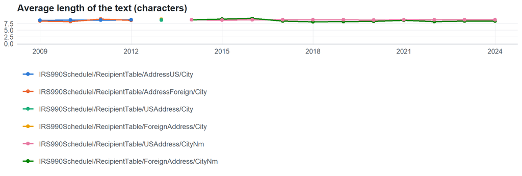

**Table view**

Table view: length and variety by tax year

| Series | Tax year | Filings | Avg length | Max length | Distinct values (approx.) |
| --- | --- | --- | --- | --- | --- |
| IRS990ScheduleI/RecipientTable/AddressUS/City | 2009 | 5,375 | 9 | 22 | 7,820 |
| IRS990ScheduleI/RecipientTable/AddressUS/City | 2010 | 16,862 | 9 | 22 | 11,570 |
| IRS990ScheduleI/RecipientTable/AddressUS/City | 2011 | 21,884 | 9 | 22 | 12,476 |
| IRS990ScheduleI/RecipientTable/AddressUS/City | 2012 | 24,654 | 9 | 22 | 12,600 |
| IRS990ScheduleI/RecipientTable/AddressForeign/City | 2009 | 16 | 8 | 14 | 12 |
| IRS990ScheduleI/RecipientTable/AddressForeign/City | 2010 | 48 | 8 | 20 | 27 |
| IRS990ScheduleI/RecipientTable/AddressForeign/City | 2011 | 58 | 9 | 37 | 84 |
| IRS990ScheduleI/RecipientTable/AddressForeign/City | 2012 | 63 | 9 | 22 | 39 |
| IRS990ScheduleI/RecipientTable/USAddress/City | 2013 | 27,474 | 9 | 22 | 10,181 |
| IRS990ScheduleI/RecipientTable/ForeignAddress/City | 2013 | 91 | 9 | 22 | 53 |
| IRS990ScheduleI/RecipientTable/USAddress/CityNm | 2014 | 30,396 | 9 | 22 | 15,638 |
| IRS990ScheduleI/RecipientTable/USAddress/CityNm | 2015 | 32,477 | 9 | 22 | 17,304 |
| IRS990ScheduleI/RecipientTable/USAddress/CityNm | 2016 | 33,945 | 9 | 22 | 20,943 |
| IRS990ScheduleI/RecipientTable/USAddress/CityNm | 2017 | 36,928 | 9 | 22 | 17,042 |
| IRS990ScheduleI/RecipientTable/USAddress/CityNm | 2018 | 38,292 | 9 | 22 | 21,549 |
| IRS990ScheduleI/RecipientTable/USAddress/CityNm | 2019 | 39,702 | 9 | 22 | 17,936 |
| IRS990ScheduleI/RecipientTable/USAddress/CityNm | 2020 | 43,091 | 9 | 22 | 18,778 |
| IRS990ScheduleI/RecipientTable/USAddress/CityNm | 2021 | 44,833 | 9 | 22 | 20,154 |
| IRS990ScheduleI/RecipientTable/USAddress/CityNm | 2022 | 47,425 | 9 | 22 | 21,899 |
| IRS990ScheduleI/RecipientTable/USAddress/CityNm | 2023 | 48,715 | 9 | 22 | 18,230 |
| IRS990ScheduleI/RecipientTable/USAddress/CityNm | 2024 | 37,632 | 9 | 22 | 18,810 |
| IRS990ScheduleI/RecipientTable/ForeignAddress/CityNm | 2014 | 92 | 9 | 22 | 79 |
| IRS990ScheduleI/RecipientTable/ForeignAddress/CityNm | 2015 | 93 | 9 | 30 | 45 |
| IRS990ScheduleI/RecipientTable/ForeignAddress/CityNm | 2016 | 126 | 9 | 26 | 159 |
| IRS990ScheduleI/RecipientTable/ForeignAddress/CityNm | 2017 | 150 | 8 | 21 | 84 |
| IRS990ScheduleI/RecipientTable/ForeignAddress/CityNm | 2018 | 146 | 8 | 22 | 137 |
| IRS990ScheduleI/RecipientTable/ForeignAddress/CityNm | 2019 | 132 | 8 | 24 | 83 |
| IRS990ScheduleI/RecipientTable/ForeignAddress/CityNm | 2020 | 140 | 8 | 28 | 92 |
| IRS990ScheduleI/RecipientTable/ForeignAddress/CityNm | 2021 | 179 | 9 | 24 | 117 |
| IRS990ScheduleI/RecipientTable/ForeignAddress/CityNm | 2022 | 195 | 8 | 32 | 266 |
| IRS990ScheduleI/RecipientTable/ForeignAddress/CityNm | 2023 | 187 | 8 | 30 | 137 |
| IRS990ScheduleI/RecipientTable/ForeignAddress/CityNm | 2024 | 144 | 8 | 32 | 114 |

Most common values by xpath (all years; long values truncated)

| Series | Value | Filings | Share |
| --- | --- | --- | --- |
| IRS990ScheduleI/RecipientTable/AddressUS/City | NEW YORK | 4,343 | 6.3% |
| IRS990ScheduleI/RecipientTable/AddressUS/City | WASHINGTON | 3,768 | 5.5% |
| IRS990ScheduleI/RecipientTable/AddressUS/City | CHICAGO | 2,489 | 3.6% |
| IRS990ScheduleI/RecipientTable/AddressUS/City | BOSTON | 1,930 | 2.8% |
| IRS990ScheduleI/RecipientTable/AddressUS/City | LOS ANGELES | 1,787 | 2.6% |
| IRS990ScheduleI/RecipientTable/AddressUS/City | SAN FRANCISCO | 1,746 | 2.5% |
| IRS990ScheduleI/RecipientTable/AddressUS/City | ATLANTA | 1,606 | 2.3% |
| IRS990ScheduleI/RecipientTable/AddressUS/City | BALTIMORE | 1,462 | 2.1% |
| IRS990ScheduleI/RecipientTable/AddressUS/City | PHILADELPHIA | 1,102 | 1.6% |
| IRS990ScheduleI/RecipientTable/AddressUS/City | SEATTLE | 978 | 1.4% |
| IRS990ScheduleI/RecipientTable/AddressUS/City | COLUMBUS | 911 | 1.3% |
| IRS990ScheduleI/RecipientTable/AddressUS/City | New York | 253 | 0.4% |
| IRS990ScheduleI/RecipientTable/AddressUS/City | Washington | 243 | 0.4% |
| IRS990ScheduleI/RecipientTable/AddressUS/City | Chicago | 173 | 0.3% |
| IRS990ScheduleI/RecipientTable/AddressUS/City | Atlanta | 147 | 0.2% |
| IRS990ScheduleI/RecipientTable/AddressUS/City | Los Angeles | 142 | 0.2% |
| IRS990ScheduleI/RecipientTable/AddressUS/City | Baltimore | 140 | 0.2% |
| IRS990ScheduleI/RecipientTable/AddressUS/City | Boston | 140 | 0.2% |
| IRS990ScheduleI/RecipientTable/AddressForeign/City | TORONTO | 10 | 5.4% |
| IRS990ScheduleI/RecipientTable/AddressForeign/City | LONDON | 8 | 4.3% |
| IRS990ScheduleI/RecipientTable/AddressForeign/City | San Juan | 4 | 2.2% |
| IRS990ScheduleI/RecipientTable/AddressForeign/City | SAN JUAN | 4 | 2.2% |
| IRS990ScheduleI/RecipientTable/AddressForeign/City | Toronto | 4 | 2.2% |
| IRS990ScheduleI/RecipientTable/AddressForeign/City | BAYAMON | 2 | 1.1% |
| IRS990ScheduleI/RecipientTable/AddressForeign/City | Hatillo | 2 | 1.1% |
| IRS990ScheduleI/RecipientTable/AddressForeign/City | MONTREAL | 2 | 1.1% |
| IRS990ScheduleI/RecipientTable/AddressForeign/City | Abuja | 2 | 1.1% |
| IRS990ScheduleI/RecipientTable/AddressForeign/City | BARRIGADA | 2 | 1.1% |
| IRS990ScheduleI/RecipientTable/AddressForeign/City | JERUSALEM | 2 | 1.1% |
| IRS990ScheduleI/RecipientTable/AddressForeign/City | Oxford | 2 | 1.1% |

First rows shown.

## Examples

| Tax year | Return | Xpath | Organization | Value | Source |
| --- | --- | --- | --- | --- | --- |
| 2024 | 990 | IRS990ScheduleI/RecipientTable/ForeignAddress/CityNm | EDUCATIONAL CREDIT | PONCE | [XML](https://gt990datalake-rawdata.s3.amazonaws.com/EfileData/XmlFiles/202503199349301740_public.xml) |
| 2024 | 990 | IRS990ScheduleI/RecipientTable/USAddress/CityNm | Associated Colleges of Illinois Inc | Rock Island | [XML](https://gt990datalake-rawdata.s3.amazonaws.com/EfileData/XmlFiles/202533189349311118_public.xml) |
| 2023 | 990 | IRS990ScheduleI/RecipientTable/ForeignAddress/CityNm | Dustins Green House Memorial Inc | Kanungu | [XML](https://gt990datalake-rawdata.s3.amazonaws.com/EfileData/XmlFiles/202403329349301505_public.xml) |
| 2023 | 990 | IRS990ScheduleI/RecipientTable/USAddress/CityNm | LOUISVILLE PROFESSIONAL FIREFIGHTERS | CHICAGO | [XML](https://gt990datalake-rawdata.s3.amazonaws.com/EfileData/XmlFiles/202423209349320882_public.xml) |
| 2022 | 990 | IRS990ScheduleI/RecipientTable/ForeignAddress/CityNm | Delmarva Education Association | Cookstown | [XML](https://gt990datalake-rawdata.s3.amazonaws.com/EfileData/XmlFiles/202333189349308653_public.xml) |
| 2022 | 990 | IRS990ScheduleI/RecipientTable/USAddress/CityNm | HOUSTON PRODUCERS’ FORUM | WACO | [XML](https://gt990datalake-rawdata.s3.amazonaws.com/EfileData/XmlFiles/202321309349304417_public.xml) |
| 2021 | 990 | IRS990ScheduleI/RecipientTable/ForeignAddress/CityNm | THOROUGHBRED CHARITIES OF AMERICA INC | ETOBICOKE | [XML](https://gt990datalake-rawdata.s3.amazonaws.com/EfileData/XmlFiles/202212499349300341_public.xml) |
| 2021 | 990 | IRS990ScheduleI/RecipientTable/USAddress/CityNm | CAMP JOHN MARC FOUNDATION INC | DALLAS | [XML](https://gt990datalake-rawdata.s3.amazonaws.com/EfileData/XmlFiles/202241039349300339_public.xml) |
| 2020 | 990 | IRS990ScheduleI/RecipientTable/ForeignAddress/CityNm | HUNTER COLLEGE ELEMENTARY SCHOOL PARENT | BROOK GREEN | [XML](https://gt990datalake-rawdata.s3.amazonaws.com/EfileData/XmlFiles/202231369349314938_public.xml) |
| 2020 | 990 | IRS990ScheduleI/RecipientTable/USAddress/CityNm | The CareSource Foundation | Dayton | [XML](https://gt990datalake-rawdata.s3.amazonaws.com/EfileData/XmlFiles/202123169349306582_public.xml) |
| 2019 | 990 | IRS990ScheduleI/RecipientTable/ForeignAddress/CityNm | Musaadah Charity | Jarash | [XML](https://gt990datalake-rawdata.s3.amazonaws.com/EfileData/XmlFiles/202033169349305518_public.xml) |
| 2019 | 990 | IRS990ScheduleI/RecipientTable/USAddress/CityNm | The Textile Museum | WASHINGTON | [XML](https://gt990datalake-rawdata.s3.amazonaws.com/EfileData/XmlFiles/202012819349301126_public.xml) |

## Reviewer checklist

- The definition matches the form line and instructions for every xpath’s schema years.
- Every xpath pooled here measures the same thing on the 990 and 990-EZ (close enough for analysis).
- The coverage chart has no unexplained gaps or jumps between tax years.
- Each open flag is fixed, or accepted with a note in validation_log.csv.
- Values answer the question on the form line (not another line’s explanation).
- Boilerplate such as ‘See Schedule O’ or ‘N/A’ is expected here, or should be treated as missing.
- Text that is really a number or a code is flagged for a different data type.

Record the review as a row in `inst/extdata/src/validation_log.csv` (variable_name, reviewer, date, status, note). Evidence built 2026-09-23 17:09:04 MST from the ef2 DuckDB builds (tax years 2009–2024).